# Lecture 4: Measures of Dispersion (POLS 3316: Statistics for Political Science, Summer 2022)

Tom Hanna

## Measures of Dispersion or Variation

We’ll be using sample data from the USArrests data in R, specifically the data on arrests for assault and percent urban population. This is state level data, with 50 observations.

```r
arrests_data <- USArrests[2:3]
```

First, we’ll get acquainted with our data by looking at the *head* of the dataframe and two *measures of central tendency* that we talked about yesterday, the *mean* and *median*.

```r
#get the first 6 rows of the data
head(arrests_data)
```

|  | Assault | UrbanPop |
| --- | --- | --- |
| Alabama | 236 | 58 |
| Alaska | 263 | 48 |
| Arizona | 294 | 80 |
| Arkansas | 190 | 50 |
| California | 276 | 91 |
| Colorado | 204 | 78 |

```r
NA
```

```r
#get the mean for both variables and store the means in objects
mean_assault_arrests <- mean(arrests_data$Assault)
mean_urban_population <- mean(arrests_data$UrbanPop)

#print the means to the screen
mean_assault_arrests
```

```
[1] 170.76
```

```r
mean_urban_population
```

```
[1] 65.54
```

```r
#get the medians and store as objects
median_assault_arrests <- median(arrests_data$Assault)
median_urban_population <- median(arrests_data$UrbanPop)
```

Measures of dispersion typically look at how the data is scattered around the mean. Let’s look at that visually. First the mean of *Assault*:

```r
library(ggplot2)

plot(arrests_data$UrbanPop,arrests_data$Assault)
abline(h = mean_assault_arrests)
```

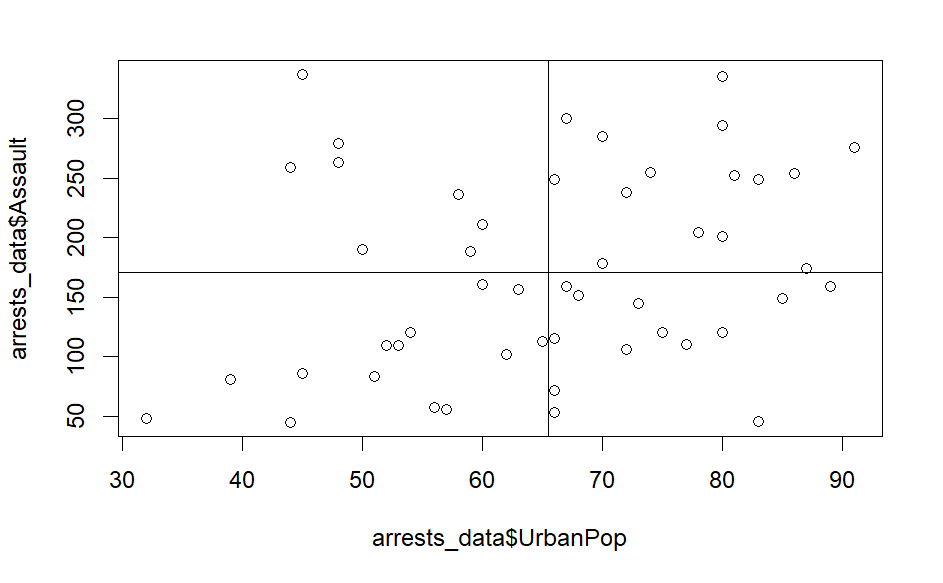

```r
abline(v = mean_urban_population)
```

```r
NA
NA
```

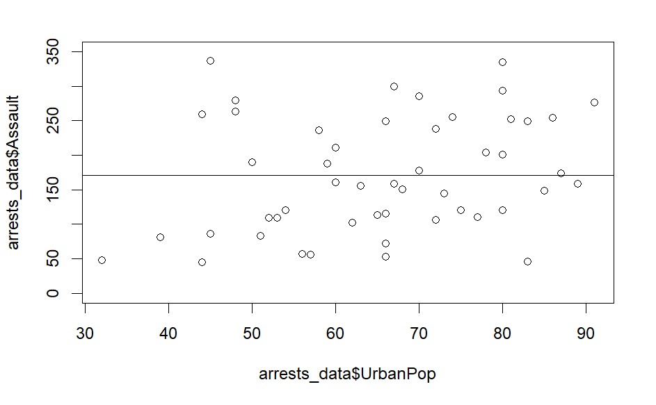

```r
plot(arrests_data$UrbanPop,arrests_data$Assault, ylim = c(0,350))
abline(h = mean_assault_arrests)
```

Suppose we had a very simple data set with only two observations - 5 and 15. The mean is 10. One is 5 above the mean and one is 5 below the mean. The data:

```r
simple_data <- c(5,15)

#The two data points called from simple_data
point1 <- simple_data[1]
cat('Point 1')
```

```
Point 1
```

```r
point1
```

```
[1] 5
```

```r
point2 <- simple_data[2]
cat('Point 2')
```

```
Point 2
```

```r
point2
```

```
[1] 15
```

```r
cat(sep = "\n")
```

```r
#the mean
simple_mean <- mean(simple_data)
cat('The mean')
```

```
The mean
```

```r
simple_mean
```

```
[1] 10
```

So, the distance from the mean is:

```r
point1_dist <- simple_data[1] - simple_mean

cat('Distance 1')
```

```
Distance 1
```

```r
point1_dist
```

```
[1] -5
```

```r
point2_dist <- simple_data[2] - simple_mean

cat('Distance 2')
```

```
Distance 2
```

```r
point2_dist
```

```
[1] 5
```

So, we want our new measure *total_variation* to equal the sum of the distances:

```r
variation <- point1_dist + point2_dist

cat('The variation is:')
```

```
The variation is:
```

```r
variation
```

```
[1] 0
```

**Math comes to the rescue!**

What is something we can do that turns a negative number into a positive number every time and leaves a positive number as a positive? It’s also important that any effect it has on the actual size of the numbers is consistent between positive and negative numbers.

```r
squared_1 <- point1_dist^2
squared_1
```

```
[1] 25
```

```r
squared_2 <- point2_dist^2
squared_2
```

```
[1] 25
```

Squaring 5 turned it into 25 and squaring -5, which is the same size but negative, also turned it into 25. So, now we can add them to get a measure of *total_variation*.

```r
total_variation <- squared_1 + squared_2

cat('Total variation is:')
```

```
Total variation is:
```

```r
total_variation
```

```
[1] 50
```

We’re almost there, but suppose we had 1000 observations, still had a mean of 10 and they were still each 5 points away. What would our total variation be?

Given that the actual average distances is exactly the same for both groups, does that make sense?

So, the hint for the solution is that we want the average of the distances or at least the average of the squared differences. So our measure of *variance* is in the simplest form:

```r
simple_variance <- (squared_1 + squared_2)/2

cat('The variance:')
```

```
The variance:
```

```r
simple_variance
```

```
[1] 25
```

```r
#This is the population variance
#R actually computes the sample variance
#To convert the two we can multiply times (n-1)/n
#In this case, n = 2

simple_variance_check <- var(simple_data) * (2-1)/2
cat('Checking with R')
```

```
Checking with R
```

```r
simple_variance_check
```

```
[1] 25
```

Now, adding all those squares in did inflate number relative to the size of the mean. In this case, 25 is 2.5 times the mean. One way we can account for this at least partially is take the square root of the variance. That gives us the *standard deviation*.

```r
simple_standard_deviation <- sqrt(simple_variance)

cat('Standard deviation is:')
```

```
Standard deviation is:
```

```r
simple_standard_deviation
```

```
[1] 5
```

```r
simple_sd_check <- sqrt(simple_variance_check)
cat('Checking with R:')
```

```
Checking with R:
```

```r
simple_sd_check
```

```
[1] 5
```